# 07_E_TSDecomposition_Algorithms

# Libraries

```r
library(fpp3)
library(seasonal)
library(fma)
```

# Features of a good decomposition

Keep these two features in mind all session. They are how you judge one decomposition against another.

1. A good decomposition leaves a **remainder** whose **variance is smaller than that of the trend and seasonal components**. Put the other way around: the trend and the season should account for most of the movement in the series, and the leftovers should be small. The component is called `random` by `classical_decomposition()` and `irregular` by some other methods; all three words mean the same thing.
2. A good decomposition leaves a remainder with **as little autocorrelation as possible**. Structure left in the remainder is structure the trend and the season failed to capture, so the closer the remainder comes to white noise, the better. That is Session 4’s correlogram, now pointed at what the model missed.

**Sometimes no decomposition satisfies both features across the whole series.** When that happens, take the one that comes closest, and say where it falls short.

# Classical Decomposition

Classical decomposition is the first algorithm we study. It rarely gives the best decomposition, but it is simple enough to build by hand, and building it is what makes the idea stick.

Group Assignment 1 goes through this algorithm in detail. For now:

- **It estimates the trend with a moving average**, which is Session 6’s material.
- It can be applied **both to additive and multiplicative schemes**. For each of these, the algorithm changes slightly (as we will see).
- **It has real limitations.** The biggest is that **it assumes the seasonal component never changes**.
  - No estimate of the trend-cycle or the remainder for the first few and last observations.
  - Seasonal component repeats from year to year (remains constant)
  - Not robust enough against unusual values or outliers in the series.

Below is an example. First let us filter the dataset:

```r
# Filter the series and select relevant columns
us_retail_employment <- us_employment |>
  filter(year(Month) >= 1990, Title == "Retail Trade") |>
  select(-Series_ID)
```

Now the decomposition. It is split into steps below so you can see what each one returns, and then written again as a single pipeline.

1. **Fit the model.** The output is a table with the different models fitted (we will see later that the `fpp3` library calls this a `mable`, short for *model table*):

```r
# Let us compute the classical decomposition using the function in the feasts library:
classical_dec <- us_retail_employment |>

  # Fit model
  model(
    classical = classical_decomposition(Employed, type = "additive")
  )

# Examine the output
classical_dec
```

```
# A mable: 1 x 1
        classical
          <model>
1 <DECOMPOSITION>
```

2. **Extract the components from the decomposition model using `components()`** on the model object:

```r
classical_comps <-
  classical_dec |>
  components()

# Examine the output
classical_comps
```

```
# A dable: 357 x 7 [1M]
# Key:     .model [1]
# :        Employed = trend + seasonal + random
   .model       Month Employed  trend seasonal random season_adjust
   <chr>        <mth>    <dbl>  <dbl>    <dbl>  <dbl>         <dbl>
 1 classical 1990 Jan   13256.    NA    -75.5   NA           13331.
 2 classical 1990 Feb   12966.    NA   -273.    NA           13239.
 3 classical 1990 Mar   12938.    NA   -253.    NA           13191.
 4 classical 1990 Apr   13012.    NA   -190.    NA           13203.
 5 classical 1990 May   13108.    NA    -88.9   NA           13197.
 6 classical 1990 Jun   13183.    NA    -10.4   NA           13193.
 7 classical 1990 Jul   13170. 13178.   -13.3    5.65        13183.
 8 classical 1990 Aug   13160. 13161.    -9.99   8.80        13169.
 9 classical 1990 Sep   13113. 13141.   -87.4   59.9         13201.
10 classical 1990 Oct   13185. 13117.    34.6   33.8         13151.
# ℹ 347 more rows
```

3. **Plot the components** (in case you want to)

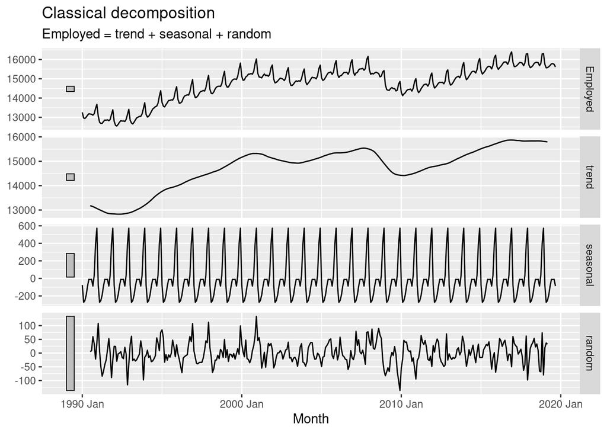

```r
classical_comps |>

  # Generate a time plot of the components
  autoplot()
```

The same thing in one pipeline. The rest of the notebook uses this form:

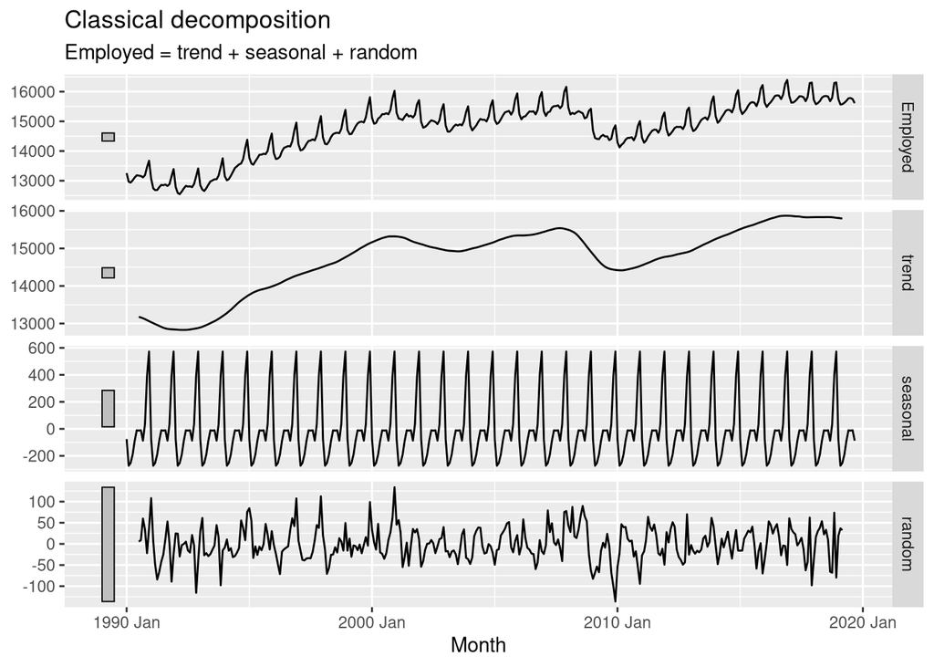

```r
us_retail_employment |>

  # Fit model
  model(
    classical = classical_decomposition(Employed, type = "additive")
  ) |>

  # Extract components
  components() |>

  # Plot (if you want to)
  autoplot()
```

# STL Decomposition

Acronym for *“Seasonal and Trend Decomposition using LOESS”*

**LOESS**: a method of **local regression**, used to estimate non-linear relationships. It stands for *LOcally Estimated Scatterplot Smoothing*.

Roughly, a LOESS curve is built like this:

Suppose you have $n$ pairs of data points $(x_i, y_i)$. The LOESS regression curve is built as follows:

- A positive integer $q < n$ is chosen ($n$ = number of points).
- For each point $x_i$, the $q$ data points closest to it are selected.
  - Each is given a neighborhood weight based on its distance to $x_i$.
  - The closer a point is to $x_i$, the greater its weight.
- These weights are then used to fit a local polynomial of degree $d$ to the data.
  - For STL $d$ = 1 or 2. That is, the fit is locally linear or locally quadratic.

So each local fit uses the nearest neighbors of the point being fitted. You never have to choose a global formula for the whole series, only a shape for the local pieces.

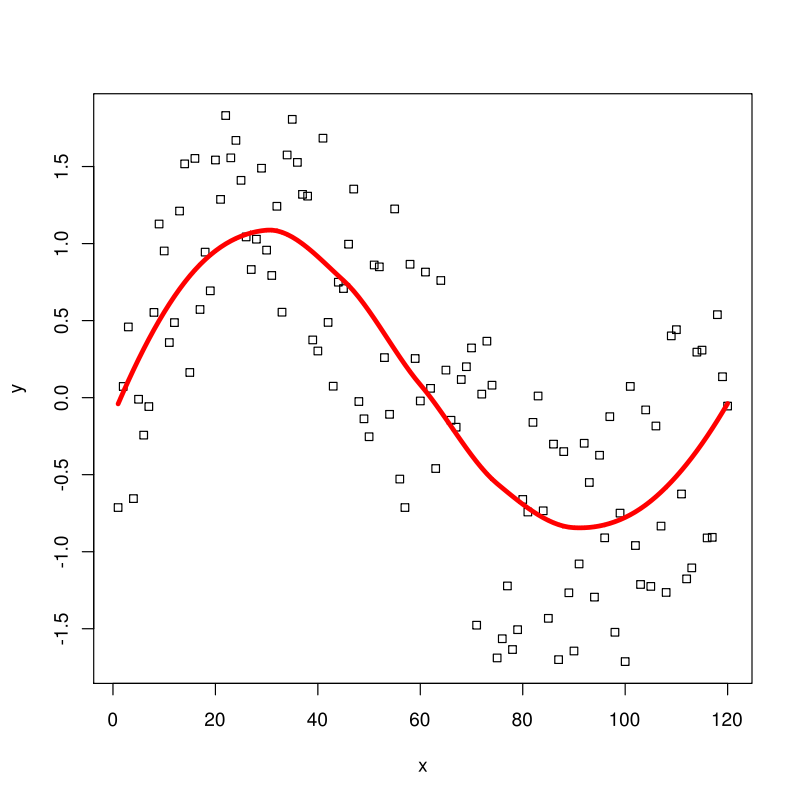

The **STL algorithm** applies LOESS repeatedly to pull the components apart.

## STL Advantages

- Handles any type of seasonality (not only monthly or quarterly)
- Seasonal component allowed to change over time.
  - Rate of change can be controlled by the user.
- The `fpp3` version handles multiple seasonal periods at once. We use that later in the course.
- The smoothness of the trend-cycle can also be controlled by the user
- It can be robust to outliers
  - With `robust = TRUE`, occasional unusual observations are kept out of the trend-cycle and seasonal estimates. They still land in the remainder component.

## STL Disadvantages

- Does not handle trading day or calendar variation automatically.
- Only works for additive decompositions
  - Multiplicative schemes can be made additive with a log transformation.
  - Decompositions that are between additive and multiplicative can be obtained using a Box-Cox transformation
- Might require user tuning to fit the LOESS windows

## STL main parameters

Both windows answer the same question: **how slowly do you believe this component should be allowed to change?** Everything below is that question, written twice.

- **Trend-cycle window** `trend(window = ?)`
  - Controls how rapidly the trend-cycle component changes.
  - Smaller values for more rapid changes.
  - Number of consecutive observations to be used when estimating the trend.
  - Must be an ODD number.
- **Seasonal window** `season(window = ?)`
  - Controls how rapidly the seasonal component changes
  - Smaller values for more rapid changes.
  - Number of consecutive seasons to be used in estimating each value of the seasonal component.
  - That counts **seasons, not observations**. With monthly data, `season(window = 11)` estimates each December’s effect from a neighbourhood of 11 Decembers, which is 11 years of them.
  - Must be an ODD number.
  - `season(window = 'periodic')` makes the seasonal window *infinite*: every value of the seasonal component is computed from the whole series, so the same points go into every window and the seasonal component comes out constant.
    - This is similar to what classical decomposition does.
- **Default values**
  - `season(window = 11)`. This usually provides a good balance between **overfitting the seasonality and allowing it to slowly change over time**.
  - `trend(window = ...)` has no single default: it is computed from the seasonal period, as `nextodd(ceiling(1.5 * period / (1 - 1.5 / season_window)))`. With the default seasonal window that works out at **21 for monthly data** (period 12) and **13 for daily data with a weekly season** (period 7).
  - The practical consequence: *“the default trend window”* is only meaningful once you know the seasonal period of the series in front of you.

## STL Example 1

Back to `us_retail_employment`, built earlier in this notebook:

1. Create model object

```r
stl_dcmp_1 <-
  us_retail_employment |>
  model(stl = STL(Employed)) |>
  components()
```

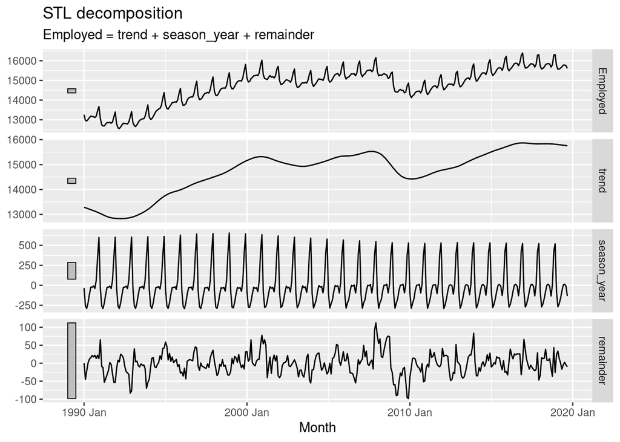

```r
stl_dcmp_1 |> autoplot()
```

## STL Example 2

Two rules before you start:

1. **Move one window at a time.** Change both and you learn nothing about which one helped.
2. **Judge the result on the remainder’s correlogram, not on how the trend line looks.** The picture improves long before the diagnostic does.

**NOTE**: the code below has a **bug**. You need to

1. Replace `"TODO"` with the default values for this series: 21 for the trend, 11 for the season.
2. Correct the syntax so that the code runs.

```r
us_retail_employment |>
  model(
    STL(Employed ~ trend(window = "TODO") + # the default for monthly data

                   season(window = "TODO"), # the default
        ) |>
  components() |>
  autoplot()
```

### Step A: the trend window

Run the decomposition four times, at `trend(window = )` of **21, 13, 9 and 5**, leaving `season(window = 11)` alone throughout. Each time, record the variance of the remainder and look at the remainder’s correlogram.

Before you run anything, write down which window you expect to give the smallest remainder variance. That prediction is the point of this step.

```r
stl_trend <- function(w) {
  us_retail_employment |>
    model(STL(Employed ~ trend(window = w) + season(window = 11))) |>
    components()
}

# Fill this in for w = 21, 13, 9, 5.
stl_trend(21) |> ACF(remainder) |> autoplot()
```

### Step B: the seasonal window

With the trend window settled, turn to the other knob. This one is judged on the **seasonal** component rather than on the remainder: track a single seasonal factor across the years and see what each window lets it do.

```r
# Hold trend(window = ) at whatever step A settled on, then compare
# season(window = 5), season(window = 11) and season(window = "periodic").
# Plot the December seasonal factor year by year for each of the three.
```

### An aside on `robust = TRUE`

`STL()` also takes a `robust` argument, and a series with a recession in it looks like exactly the place to reach for it. Run your chosen windows both ways and decide whether it helps here. Think about what robustness is being asked to do to the 2008 observations before you look at the numbers.

### The decomposition this example arrives at

Put the two windows you chose together and plot the components one last time. Check it against the two criteria from the top of this notebook, and be ready to say which window earned which part of the improvement.

## STL Example 3

Labour force in Australia - Decomposition

The series `labour` counts the people in the Australian civilian labour force, monthly, from February 1978 to August 1995.

You need to **install and load the `fma` package** for this series to be available.

```
Plot variable not specified, automatically selected `.vars = value`
```

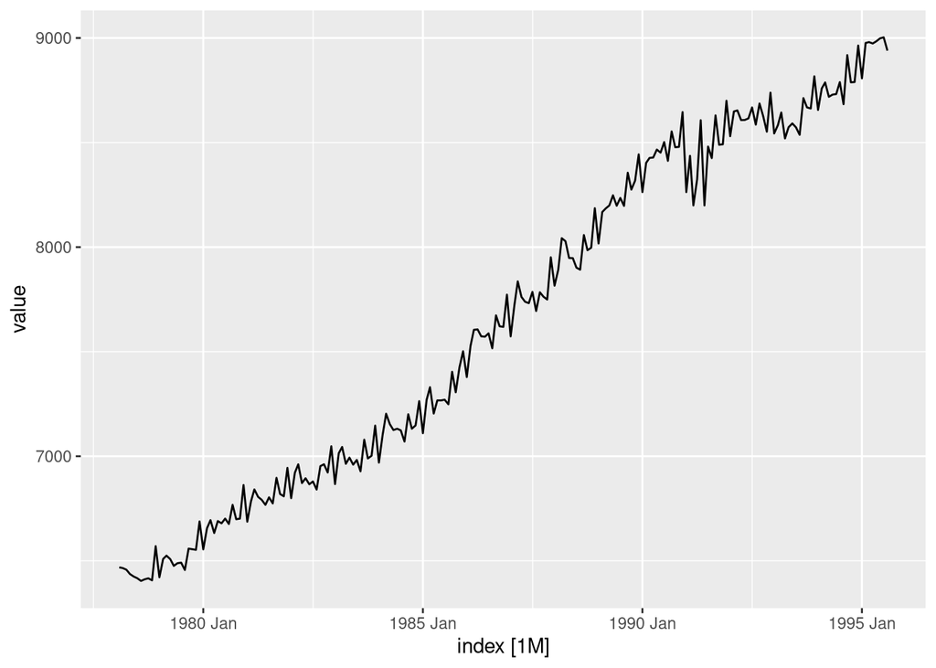

```r
labour_tsibble <- as_tsibble(labour)
autoplot(labour_tsibble)
```

### 1.1 Default STL decomposition

Run an STL decomposition with the default trend and seasonal windows, that is, without passing any further arguments.

### 1.2 The 1991-1992 crisis

Look at the crisis around 1991-1992 and answer these questions:

- Do the trend and/or seasonal components adequately capture this crisis?
- What do you think of the time series components in the vicinity of this crisis?
- The grey bars printed on the left of the decomposition graphs when using `autoplot()` are created to compare the scale between graphs (the length of the bar is the same on all graphs). Comparing the scale of the graphs, do you think this is a good decomposition? Why or why not?
- How would you change the window parameters so that the trend better captures the 91-92 crisis? Perform several attempts to improve the STL decomposition.

# Exercise 2 - STL

Decompose the time series of the daily average electricity demand in Victoria (Australia) using an STL decomposition.

First compute daily electricity demand from `vic_elec`:

```
Plot variable not specified, automatically selected `.vars = avg_demand`
```

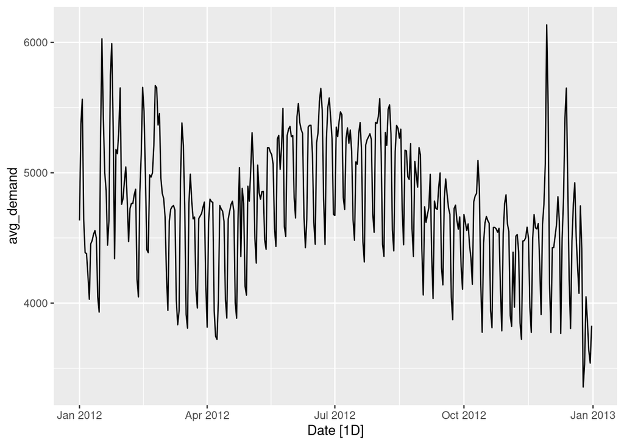

```r
vic_elec_d <-
  vic_elec |>
    index_by(Date) |>
    summarize(avg_demand = mean(Demand)) |>
    filter(year(Date) == 2012)

vic_elec_d |> autoplot()
```

This series is daily with a weekly season, so its period is 7, and the defaults work out at `trend(window = 13)` and `season(window = 11)`. The decomposition below writes them out explicitly so you can see them. Passing no arguments at all, `STL(avg_demand)`, gives exactly this result.

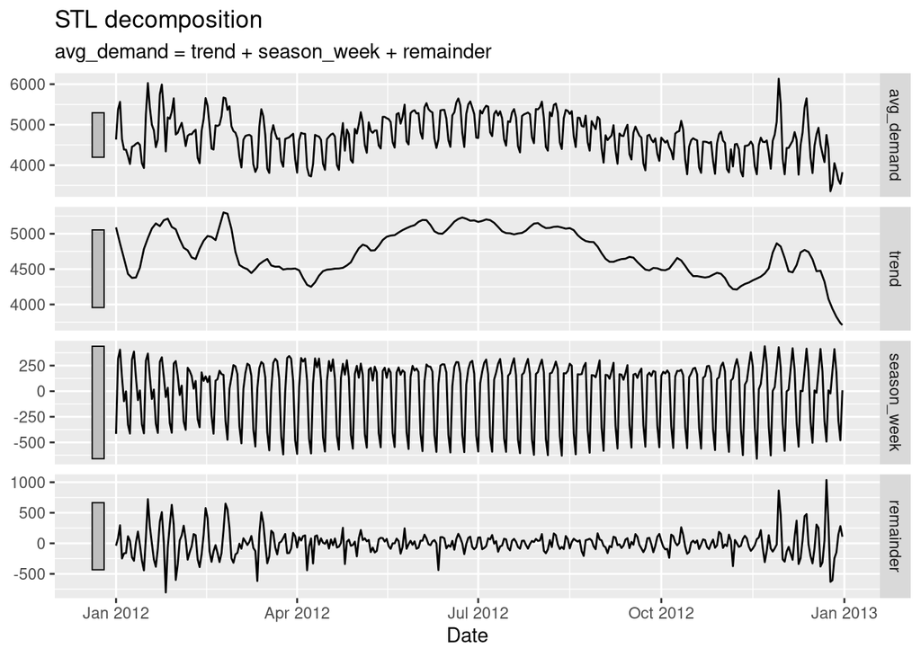

```r
dcmp_1 <-
  vic_elec_d |>
      model(
        decomp = STL(avg_demand ~ trend(window = 13) + season(window = 11))
        ) |>
      components()

dcmp_1 |> autoplot()
```

Now look at the correlogram of the remainder. It is plainly not white noise: a lot of autocorrelation is left in it.

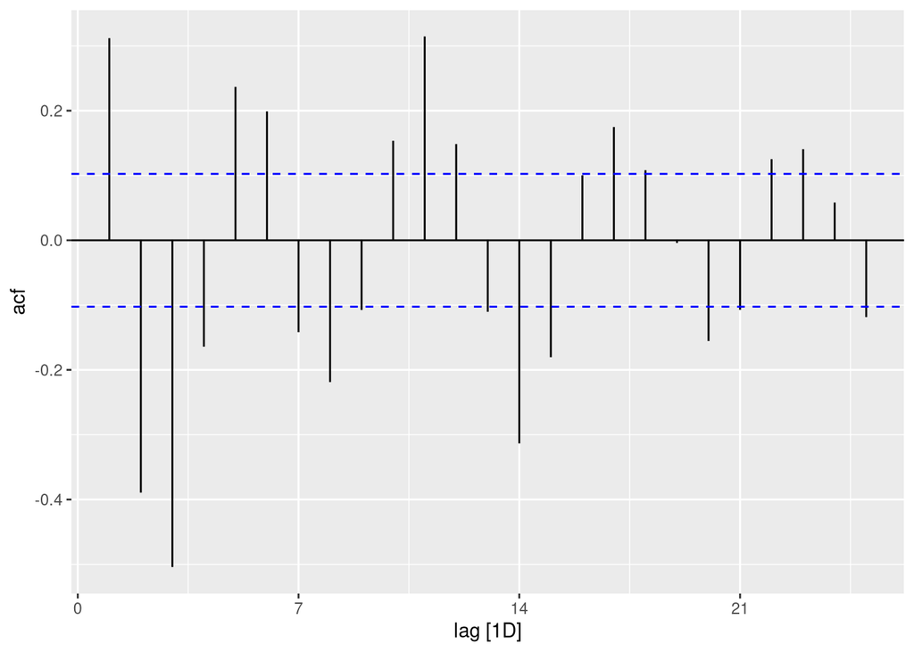

```r
dcmp_1 |>
  ACF(remainder) |>
  autoplot()
```

## 2.1 Do you see any problem with this decomposition?

## 2.2 Tuning the windows

Adjust the seasonal and trend windows to improve the decomposition as far as you can: